# 딥러닝 기초 5강(2018.09.08)

- **강의 목표**: Decision Tree
- **이론**:
- **실습**:

```r
#기본 옵션
options(repr.plot.width=4, repr.plot.height=3)
```

# 질문

Q1. Decision tree의 대표격인ㅇ CART를 중점적으로 설명해주신거죠? 설명하신게 어디까지가 decision tree의 내용인지 CART의 내용인지 잘 모르겠어요 classification도 있고 regression도 있다고 유투브에서 봐가지고요

Q2. Q. boosting 쪽에서 weak learner -> strong learner 로 필기 되어 있는데,  
bagging, boosting과 앙상블, 랜덤 포레스트와의 관계가 어떻게 되는지 궁금합니다.  
앙상블이 여러개 사용하는 거라서 랜덤포레스트와 같다는 인터넷 강의도 있어가지고요

Q3. bagging -> (unique한 나무) -> Random forest  
boosting 이런식으로 bagging과 boosting은 좀 다른 건가요? 앙상블이 여러개 썩인다로만 이해했는데 boosting은 순차적으로 들가는 거니까 좀 다른가 싶어서요

Q4. 마지막 수업에서 하이퍼 파라미터 tree 갯수를 상관하지 않아도 되는 모델이 있따고 필기했는데 random forest, mtry bagging. var/B/P boosting, B

로 다 나무 갯수는 정해줘야 하지 않나요?

(mtry가 split할때 선택될 나무의 갯수로 이해했는데 잘못 이해한거 같기도해요)

**요약**

1. Decision Tree:

   > Tree spliting rule, 파라미터 조합이 아님  
   > 어느 영역에 속하느지를 보고 output 값을 찾음  
   > https://www.youtube.com/watch?v=DCZ3tsQIoGU classification, regression 둘 다 있지만 classification을 다룰 예정
2. CART(Classification And Regression Tree) - 가장 대표적

   > 가장 잘 분할하는 속성값을 찾는 것 Decision tree <- CART, HMC, MARS ...  
   > 불순도: 다수를 차지하는 레코드 중 , 다른 것이 차지하는 비율

   > 장점: 해석이 쉬움  
   > 단점: 계산 너무 많아짐, overfitting 되기 쉬움
3. 작동 방식
   > 1. 분기로 나눠서 cost 측정
   > 2. 가장 낮은 cost 선택
   > 3. 계속 나눔
4. overfitting 피하기 위한 제한

   > Maximum depth: tree 깊이 수를 제한 eg) 나무 깊이를 3까지만 Maximum-node-size: 마지막 node의 크기 제한
1. Random Forest 정의

   > 무작위로 tree를 나눔, var를 낮춰서 overfitting을 피할 수 있음 Ensemble Machine Learning Algoristh 이라고 불림(weak learner -> strong learner)
2. Random Forest 장점
   > 1. regression/ classification 가능
   > 2. 데이터 없는 부분을 고려해서 정확도를 높일 수 있음
   > 3. overfitting 이 발생하지 않음
   > 4. 큰 데이터 set을 높은 차원에서 다룰 수 있다.
   > 5. Bagging의 correlation 문제를 해결함
3. Random Forest 단점
   > 1. regression은 classification만큼 정확하지 않음
   > 2. 학습된 범위 밖에 대해서는 설명해주지 않음(regression)
   > 3. control 하기가 어려움
1. Ensemble method(Random Forest) 알고리즘 2가지

   > Bagging/ Boosting 정의: 여러 모델을 이용하여 데이터를 학습하고, 모든 모델의 예측 결과를 평균하여 예측 사용 이유: error 최소화, overfitting 감소(variance 감소) https://www.slideshare.net/freepsw/boosting-bagging-vs-boosting
2. Bagging
   > 1. 특징: 병렬 앙상블, variance 감소
   > 2. 방식: resampling(재표본추출)해서 나온 tree들을 평균 취하기
   > 3. 장점: 안정성을 높이고, 분산과 정확도를 낮추도록 설계된 알고리즘,  
   >    분산을 줄이고 높이지만 최대치가 안했을 때 분산이랑 똑같아서 손해 보지는 않음
   > 4. 단점: 비슷한 나무가 많이 나옴 -> 그래서 random forest 사용
   > 5. Bias: 변하지 않음, 평균값을 나누는 거니까
   > 6. Var: p(row)라는 상관 계수로 조절
   > 7. hyper parameter: var(나무 1개의 분산), B(나무의 갯수), p(상관계수)
   > 8. 대표 알고리즘 : Random forest는 무작위로 tree 를 정하기 때문에, var 낮아짐(비슷한 나무가 적게 나옴)
3. Boosting
   > 1. 특징: 연속 앙상블, Bias 감소
   > 2. 방식: 편향을 낮추고, supervised learning의 분산을 낮추도록 설계된 알고리즘  
   >    직전에 학습된 모델의 잔차를 설명하는 새로운 함수를 만들며 cost를 최소화하는 것
   > 3. 적합한 상황: low var, high bias
   > 4. Bias: 변하지 않음, 평균값을 나누는 거니까
   > 5. Var: p(row)라는 상관 계수로 조절
   > 6. hyper parameter: B(나무의 갯수)
   > 7. 대표 알고리즘: gradient Boosting(loss function의 gradient에 가중치 부여), ada Boostinㅎ)

==

1. Bayes Error

   > Bayes Error = Irreducible Error, 내재된 오류
2. E[ e(h) ] = Bayes Error + [Bias(h)]^2 + Var(h)

   > 해석: Bayes Error는 어쩔수 없으니, 일반화 오류들의 기댓값 = 편향과 과 분산에 좌우됨 Decision Tree 입장에서는 나무가 많아지면 var가 커지고, overfirtting이 많아짐

==

```r
#와인 데이터 불러오기
data4_1 <- read.csv("data4_1.csv", header = TRUE) #한글 깨지지 않으려면 encoding="utf-8" 하면됨

test_df <- data4_1
colnames(test_df)
```

1. 'fixed_acidity'

2. 'volatile_acidity'

3. 'citric_acid'

4. 'residual_sugar'

5. 'chlorides'

6. 'free_sulfur_dioxide'

7. 'total_sulfur_dioxide'

8. 'density'

9. 'pH'

10. 'sulphates'

11. 'alcohol'

12. 'quality'

13. 'type'

# 1. lm로 와인데이터 그리기

```r
# 와인 데이터 불러오기
test_df <- data4_1 #wine
set.seed(10)

#use 80% of random data as a training set
train <- sample(1:nrow(test_df), 0.8*nrow(test_df))

#lm quality and other data to train(ofcourse using 80%, which is the train)
model <- lm(quality~., data=test_df[train, ])

#preidct
pred_quality <- predict(model, test_df[-train, ])
real_quality <- test_df$quality[-train]

validation_error <- mean((real_quality - pred_quality)^2)
```

0.550955108999419

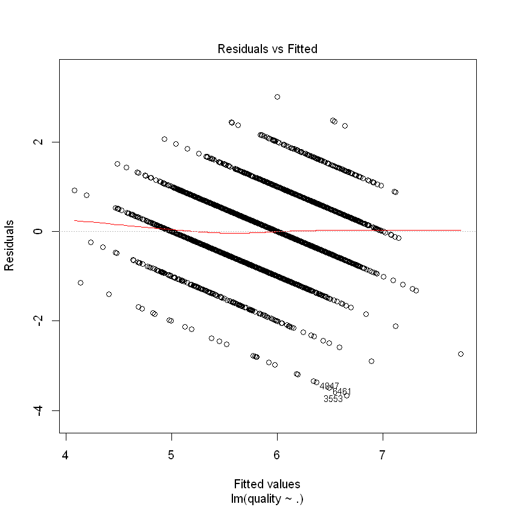

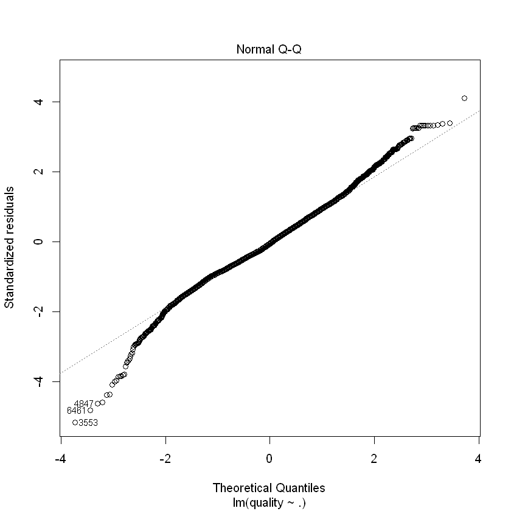

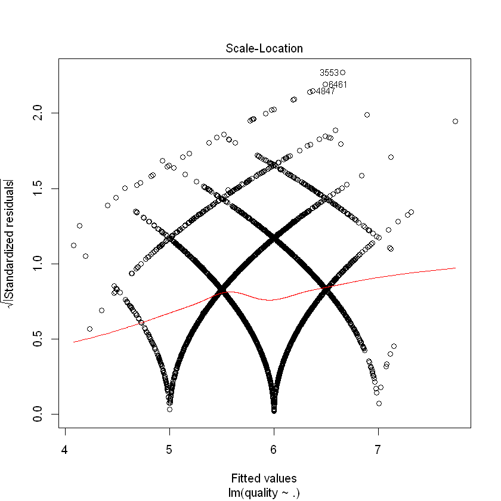

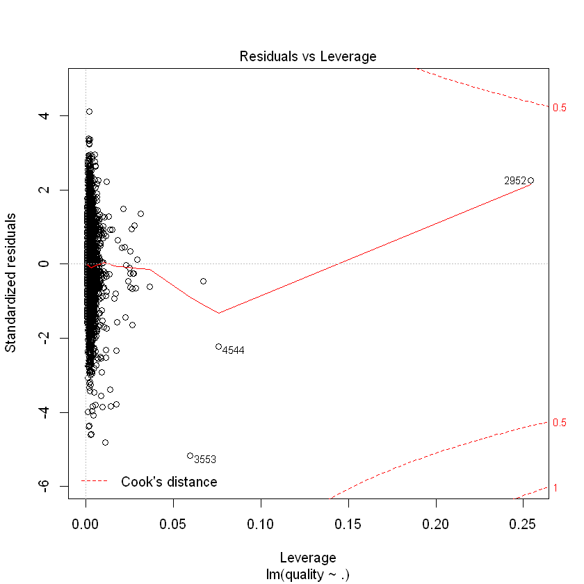

```r
#lm result
validation_error
plot(model)
```

# 2. 와인 데이터로 tree 그리기

```r
library(tree)

test_df <- data4_1 #wine
set.seed(10)

#use 80% of random data as a training set
train <- sample(1:nrow(test_df), 0.8*nrow(test_df))

#lm quality and other data to train(ofcourse using 80%, which is the train)
model <- tree(quality~., data=test_df[train, ])

#preidct
pred_quality <- predict(model, test_df[-train, ])
real_quality <- test_df$quality[-train]

validation_error <- mean((real_quality - pred_quality)^2)
```

0.567616036143317

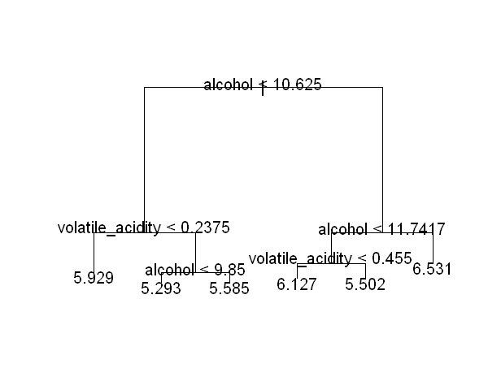

```r
options(repr.plot.width=5, repr.plot.height=4)

# tree result
# 해석은 편하지만 variance가 높아서 정확도는 떨어질 수 있음
validation_error

plot(model)
text(model)
```

# a) bagging

- 여러개를 뽑아서 평균을 구 bias는 동일함 variance를 줄일 수 있지만 비슷한 나물들이 나옴

  ρ(row)가 생각보다 작지 않아서, 여러번 코드를 돌려나무가 비슷하게 나옴 ~ 알코올, acidity 에서 크게 달라지지 않음
- hyper parementer max depth : 깊이 min node size : 마지막 node의 데이터 갯수 b: 몇개 사용할지 고려해야함

# b) random forest

- 무작위로 뽑는 것
- hyper parementer b : 나무 갯수 ~ 최적의 나무 갯수 선택해(이론), rf 는 그러지 않음(분산이 늘어나지 않으니까 특정 지점까지 괜찮음), 따라서, max depth, min node size, b : 크게 상관하지 않아도 됨

  가장 중요한 hyperparameter는 몇개 뽑을지
  - 12개 중 12게 뽑으면 bagging
  - 12개 중 n개 뽑으면 random forest(가령, 당도와 밀도를 고려하겠다) mtry를 낮추다: n 작아질수록, var 줄어듦(유니크한 나무), 늘어 mtry를 높이다; var 늘어남, biase 줄어듦

# 3. random forest 실습(ranger library로)

```r
#random forest 는 오래 걸려서 ranger 사용함
library(ranger)
```

[output not shown]

```r
test_df <- data4_1 #wine
set.seed(10)

#use 80% of random data as a training set
train <- sample(1:nrow(test_df), 0.8*nrow(test_df))

#lm quality and other data to train(ofcourse using 80%, which is the train)
model <- ranger(quality~., data=test_df[train, ])

#predict에는 $prediction 해줘야함
pred_quality <- predict(model, test_df[-train, ])$prediction
real_quality <- test_df$quality[-train]

validation_error <- mean((real_quality - pred_quality)^2)
validation_error
```

[output not shown]

mtry=1 input 1개이면, 변수 정해준거

```r
test_df <- data4_1 #wine
set.seed(10)

#use 80% of random data as a training set
train <- sample(1:nrow(test_df), 0.8*nrow(test_df))

#lm quality and other data to train(ofcourse using 80%, which is the train)
model <- ranger(quality~., data=test_df[train, ], mtry=5)

#predict에는 $prediction 해줘야함
pred_quality <- predict(model, test_df[-train, ])$prediction
real_quality <- test_df$quality[-train]

validation_error <- mean((real_quality - pred_quality)^2)
validation_error
```

[output not shown]

# c) boosting

따로 모델을 사용하지 않음

```r
test_df <- data4_1 #wine
set.seed(10)

train <- sample(1:nrow(test_df), 0.8*nrow(test_df))

model1 <- tree(quality~. ,data=test_df[train, ])
# predict(model1, test_df[train, ])
test_df$quality[train] <- test_df$quality[train] - predict(model1, test_df[train,])

model2 <- tree(quality~. ,data=test_df[train, ])
test_df$quality[train] <- test_df$quality[train] - predict(model2, test_df[train,])

model3 <- tree(quality~. ,data=test_df[train, ])
test_df$quality[train] <- test_df$quality[train] - predict(model3, test_df[train,])

model4 <- tree(quality~. ,data=test_df[train, ])
test_df$quality[train] <- test_df$quality[train] - predict(model4, test_df[train,])

model5 <- tree(quality~. ,data=test_df[train, ])
test_df$quality[train] <- test_df$quality[train] - predict(model5, test_df[train,])

model5

# 첫번째 모델로, validation set이 얼마나 학습되어있는확 확인
pred1 <- predict(model1, test_df[-train,])
# 두번째
pred2 <- predict(model2, test_df[-train,])
pred3 <- predict(model3, test_df[-train,])
pred4 <- predict(model4, test_df[-train,])
pred5 <- predict(model5, test_df[-train,])

pred <- pred1 + pred2 + pred3+ pred4 + pred5

real <- test_df$quality[-train]

mean((real - pred)^2)
```

[output not shown]

# c-1) Gradient Descent Model(GDM)

boosting 머신은 튜닝엄 엄청 해야됨, 예시는 500개 트레이닝

```r
library(gbm)
```

```r
test_df <- data4_1 #wine
set.seed(10)
#gradeint descendent는 나무 갯수 정해줘야함
tree_num=500

train <- sample(1:nrow(test_df), 0.8*nrow(test_df))
model <- gbm(quality~. ,data=test_df[train, ], n.trees=tree_num) # n.trees

pred_quality <- predict(model, test_df[-train, ], n.trees=tree_num) # n.trees
real_quality <- test_df$quality[-train]

validation_error <- mean((real_quality - pred_quality)^2)
validation_error
```

[output not shown]

# c-2) xgboost

training error는 줄어들고, validation error는 줄어들다 늘어남

```r
library(xgboost)
```

```r
test_df <- data4_1 #wine
set.seed(10)

wine_xgb <- model.matrix(quality ~., data=test_df)
label_wgb <- test_df$quality

hyperparam <- list(max_depth = 4, eta =0.1)

model <- xgboost(data=wine_xgb[train, ],
                label =label_wgb[train],
                param = hyperparam,
                nrounds =300)


pred <- predict(model, wine_xgb[-train,])
real <- test_df$quality[-train]

# Root Mean Square Error; RMSE
```

[output not shown]

```r
print(mean((real*pred)^2))
```

```
[1] 1223.215
```

**5회 수업 정리**

1. 머신러닝 기초(벡터, 행렬, 도함수)
2. Regression (Gradient)
3. Classification (MLE, MAP, Sigmoid)
4. Overfitting (VC, Cross-validation, R(h), Shrinkage:Lasso/Ridge)
5. Decision Tree(CART, Bagging/Boosting)
1. 실습  
   모델 하나씩 트레이닝 하는 것 약간 다름파라미터, 하나하나 명시해줘야함 요즘 나온 라이브러리는 자동으로 cross-validation을 해줌

**+ 2기 수업은 Cnn rnn vae gan까지 포함**